# Exploratory Data Analysis by Rahel Ghebrekidan

## Introduction

The project intends to investigate the relation between quality of wine and factors that affect it quantitatively. The quality of red wine is affected by different factors starting from how the wine was growing till how it was served. Depending on the variables given on the dataset, I am going to explore the variables which has strong relationship with the quality.

The data set is about red variants of the Portuguese “Vihno Verde” wine. It is extracted from https://www.google.com/url?q=https://s3.amazonaws.com/udacity-hosted-downloads/ud651/wineQualityReds.csv&sa=D&ust=1469921568663000&usg=AFQjCNF3NKxn9msJJYuGQuy76gX_WdOa0A.

### Objective of the project

- Perform Univariate, bivariate and multivariate analysis on the variables in the Red wine data set
- Transforming data to normalize variables distribution and/or remove outliers
- Test correlation between the variables

### Variables In the Data Set

```
## [1] 1599   13
```

There are 1599 rows(wines) and 13 variables in the data set.

#### The Variables and their unit

1 - X (case/raw number )  
2 - Fixed acidity (tartaric acid - g / dm^3)  
3 - Volatile acidity (acetic acid - g / dm^3)  
4 - Citric acid (g / dm^3)  
5 - Residual sugar (g / dm^3)  
6 - Chlorides (sodium chloride - g / dm^3  
7 - Free sulfur dioxide (mg / dm^3)  
8 - Total sulfur dioxide (mg / dm^3)  
9 - Density (g / cm^3)  
10 - PH(scale from 0 to 14)  
11 - Sulphates (potassium sulphate - g / dm3)  
12 - Alcohol (% by volume) 13 - Quality (score between 0 and 10)

# Univariate Plots and Analysis

The first 5 rows in the data set:

```
##   X fixed.acidity volatile.acidity citric.acid residual.sugar chlorides
## 1 1           7.4             0.70        0.00            1.9     0.076
## 2 2           7.8             0.88        0.00            2.6     0.098
## 3 3           7.8             0.76        0.04            2.3     0.092
## 4 4          11.2             0.28        0.56            1.9     0.075
## 5 5           7.4             0.70        0.00            1.9     0.076
##   free.sulfur.dioxide total.sulfur.dioxide density   pH sulphates alcohol
## 1                  11                   34  0.9978 3.51      0.56     9.4
## 2                  25                   67  0.9968 3.20      0.68     9.8
## 3                  15                   54  0.9970 3.26      0.65     9.8
## 4                  17                   60  0.9980 3.16      0.58     9.8
## 5                  11                   34  0.9978 3.51      0.56     9.4
##   quality
## 1       5
## 2       5
## 3       5
## 4       6
## 5       5
```

## Statistics of the Variables

```
##        X          fixed.acidity   volatile.acidity  citric.acid
##  Min.   :   1.0   Min.   : 4.60   Min.   :0.1200   Min.   :0.000
##  1st Qu.: 400.5   1st Qu.: 7.10   1st Qu.:0.3900   1st Qu.:0.090
##  Median : 800.0   Median : 7.90   Median :0.5200   Median :0.260
##  Mean   : 800.0   Mean   : 8.32   Mean   :0.5278   Mean   :0.271
##  3rd Qu.:1199.5   3rd Qu.: 9.20   3rd Qu.:0.6400   3rd Qu.:0.420
##  Max.   :1599.0   Max.   :15.90   Max.   :1.5800   Max.   :1.000
##  residual.sugar     chlorides       free.sulfur.dioxide
##  Min.   : 0.900   Min.   :0.01200   Min.   : 1.00
##  1st Qu.: 1.900   1st Qu.:0.07000   1st Qu.: 7.00
##  Median : 2.200   Median :0.07900   Median :14.00
##  Mean   : 2.539   Mean   :0.08747   Mean   :15.87
##  3rd Qu.: 2.600   3rd Qu.:0.09000   3rd Qu.:21.00
##  Max.   :15.500   Max.   :0.61100   Max.   :72.00
##  total.sulfur.dioxide    density             pH          sulphates
##  Min.   :  6.00       Min.   :0.9901   Min.   :2.740   Min.   :0.3300
##  1st Qu.: 22.00       1st Qu.:0.9956   1st Qu.:3.210   1st Qu.:0.5500
##  Median : 38.00       Median :0.9968   Median :3.310   Median :0.6200
##  Mean   : 46.47       Mean   :0.9967   Mean   :3.311   Mean   :0.6581
##  3rd Qu.: 62.00       3rd Qu.:0.9978   3rd Qu.:3.400   3rd Qu.:0.7300
##  Max.   :289.00       Max.   :1.0037   Max.   :4.010   Max.   :2.0000
##     alcohol         quality
##  Min.   : 8.40   Min.   :3.000
##  1st Qu.: 9.50   1st Qu.:5.000
##  Median :10.20   Median :6.000
##  Mean   :10.42   Mean   :5.636
##  3rd Qu.:11.10   3rd Qu.:6.000
##  Max.   :14.90   Max.   :8.000
```

# Quality of Red Wine

In the data set, the quality variable is a score given to each wine by wine experts. The scores given are in a range 0 to 10 where 0 represents very bad and 10 excellent.

```
##    Min. 1st Qu.  Median    Mean 3rd Qu.    Max.
##   3.000   5.000   6.000   5.636   6.000   8.000
```

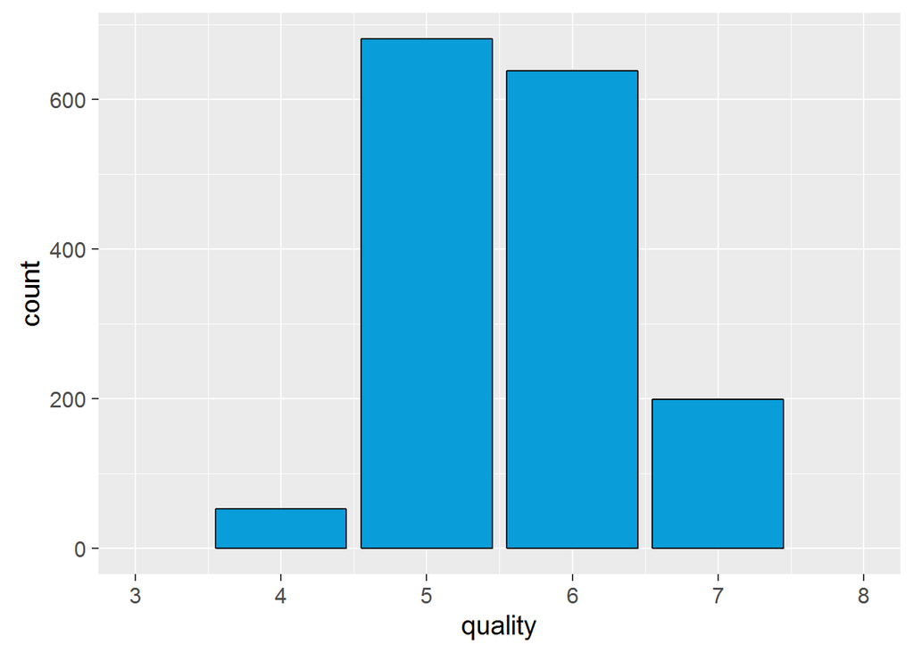

### Grouping the Variable Quality

#### Quality by number of Wines

```
## Not Good  Average     Good
##       63     1319      217
```

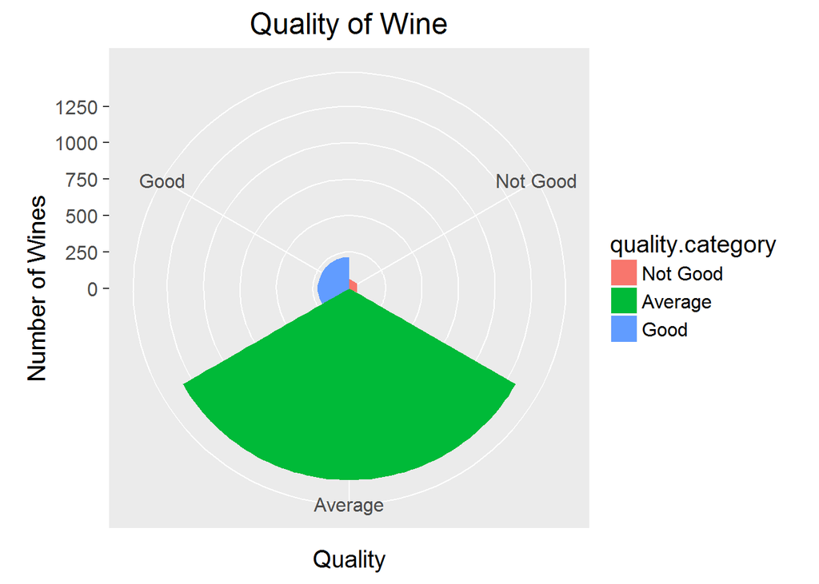

#### It is clear from the graphy that most of the wines are scored average(5 and 6).

### Distribution of Variables

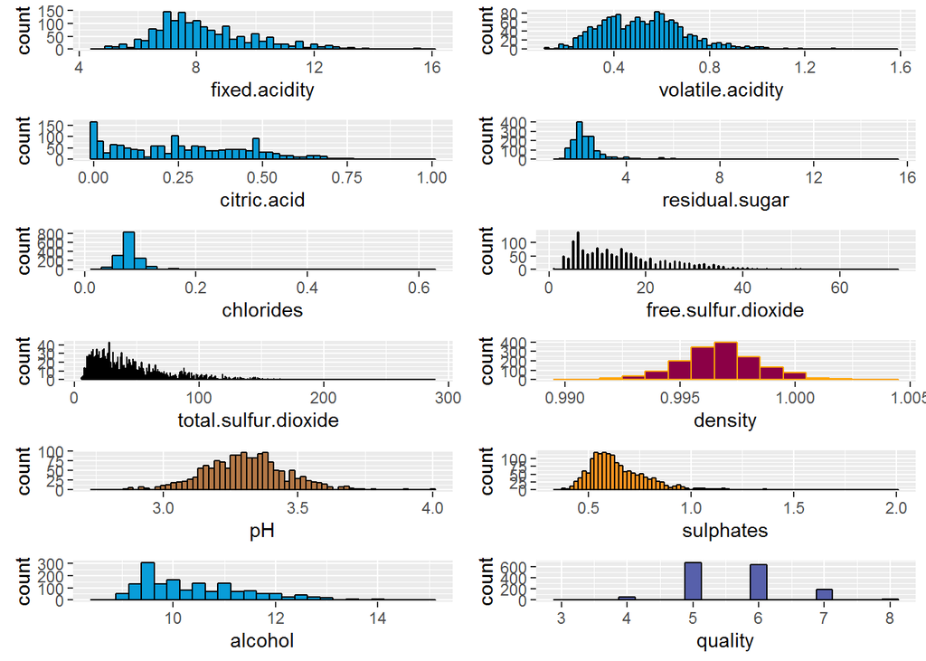

The graphs show that fixed acidity, volatile acidity,density, pH, sulphates and quality have approximately normal distribution. While free sulfur dioxide and total sulfur dioxideare not normally distributed.Citric acid, Residual Sugar, chlorides and alcohol has outliers.

### 1. Citric Acid

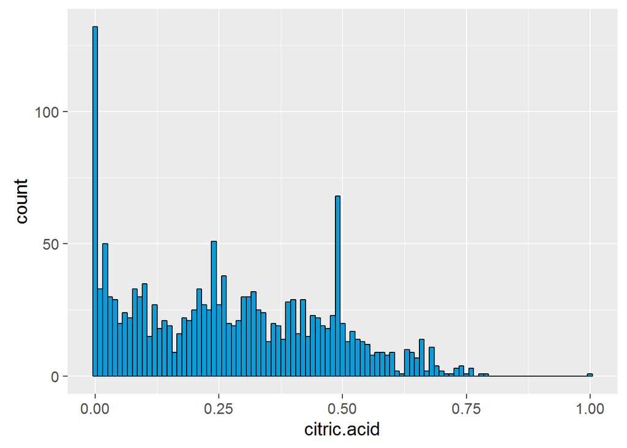

```
##    Min. 1st Qu.  Median    Mean 3rd Qu.    Max.
##   0.000   0.090   0.260   0.271   0.420   1.000
```

```
## [1] 132
```

There are 132 cases with zero citric acid.

#### Removing outliers

```
##    Min. 1st Qu.  Median    Mean 3rd Qu.    Max.
## 0.00000 0.03743 0.10040 0.09908 0.15230 0.30100
```

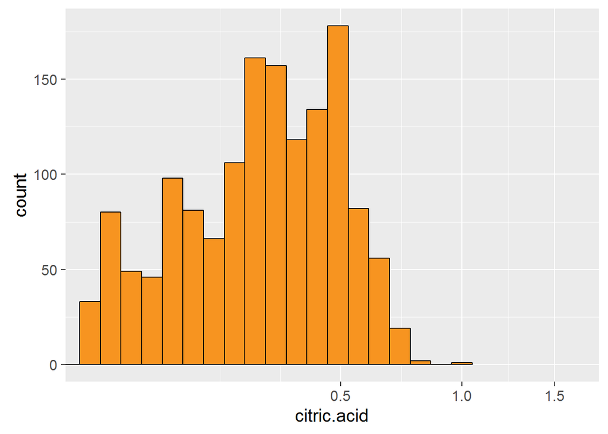

### 2. Total Sulfur Dioxide

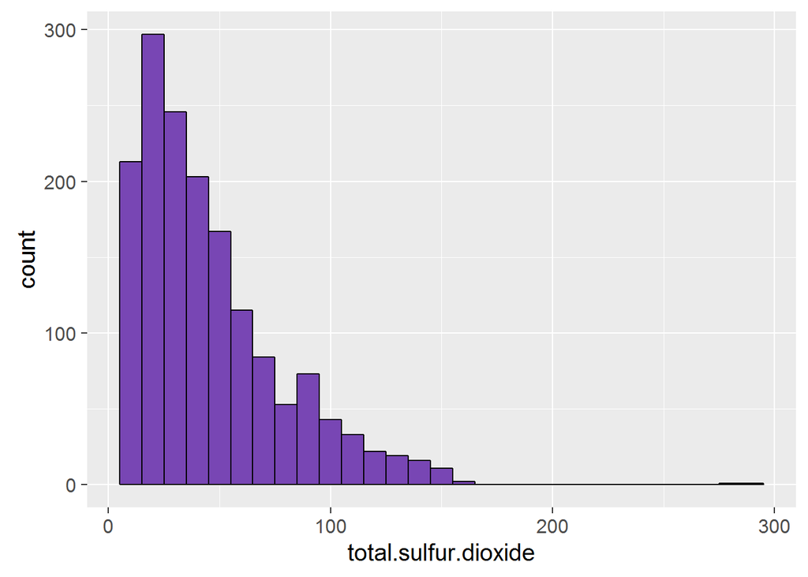

```
##    Min. 1st Qu.  Median    Mean 3rd Qu.    Max.
##    6.00   22.00   38.00   46.47   62.00  289.00
```

#### Normalizing the distribution

```
##    Min. 1st Qu.  Median    Mean 3rd Qu.    Max.
##  0.8451  1.3620  1.5910  1.5790  1.7990  2.4620
```

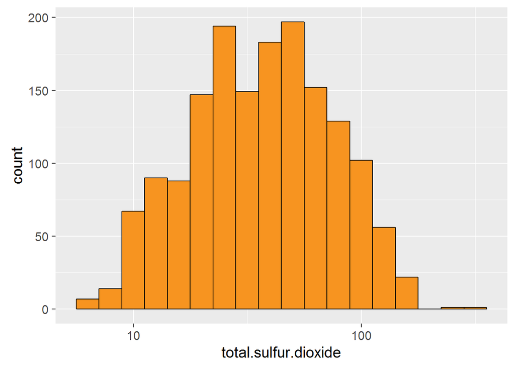

### 3. Free Sulfur Dioxide

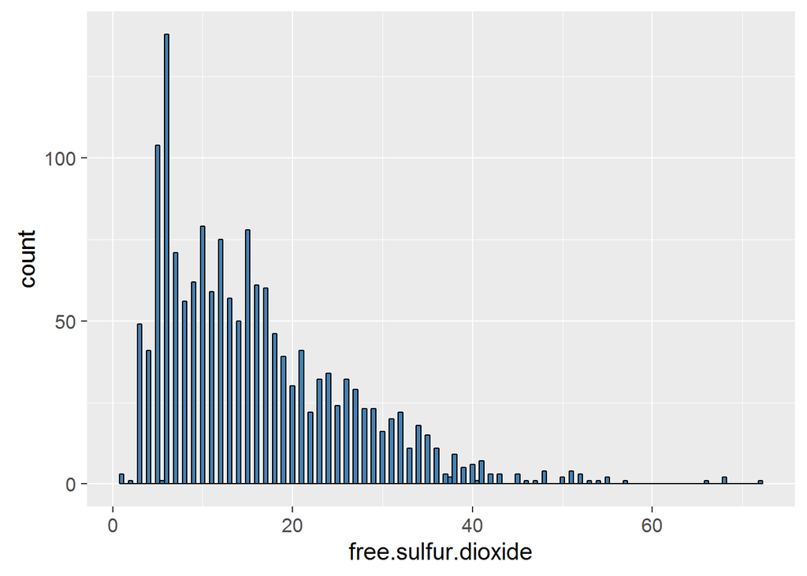

```
##    Min. 1st Qu.  Median    Mean 3rd Qu.    Max.
##    1.00    7.00   14.00   15.87   21.00   72.00
```

#### Normalizing Data

```
##    Min. 1st Qu.  Median    Mean 3rd Qu.    Max.
##  0.3010  0.9031  1.1760  1.1460  1.3420  1.8630
```

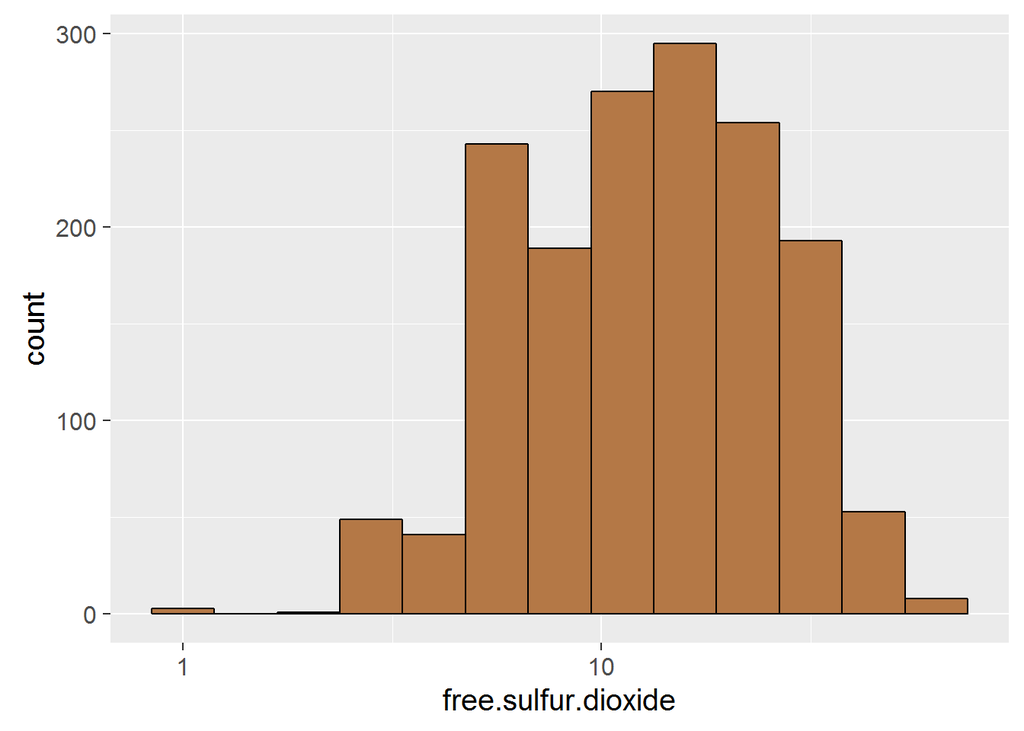

### 4. Residual Sugar

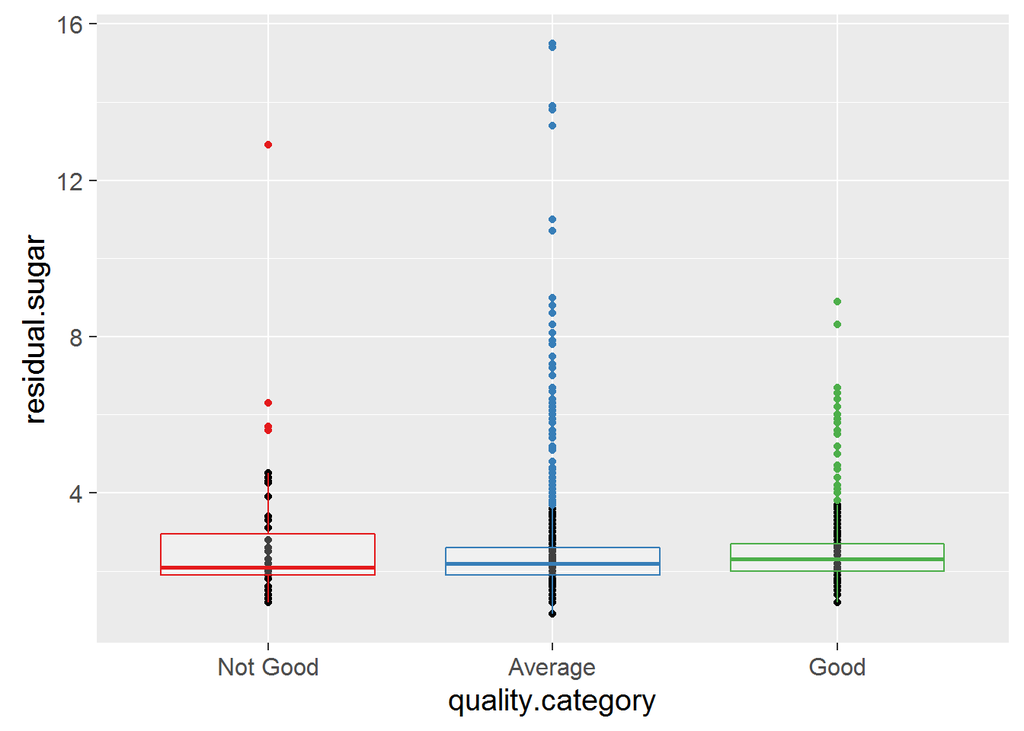

```
##    Min. 1st Qu.  Median    Mean 3rd Qu.    Max.
##   0.900   1.900   2.200   2.539   2.600  15.500
```

#### Removing outliers

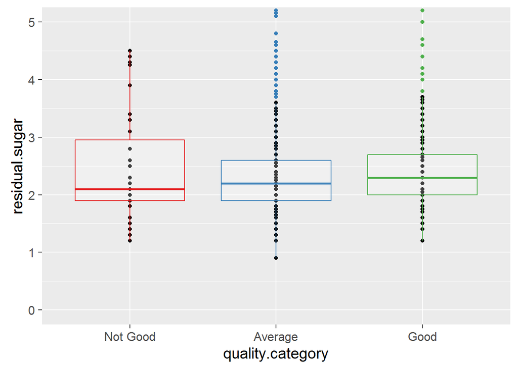

### 5. Chlorides

```
##    Min. 1st Qu.  Median    Mean 3rd Qu.    Max.
## 0.01200 0.07000 0.07900 0.08747 0.09000 0.61100
```

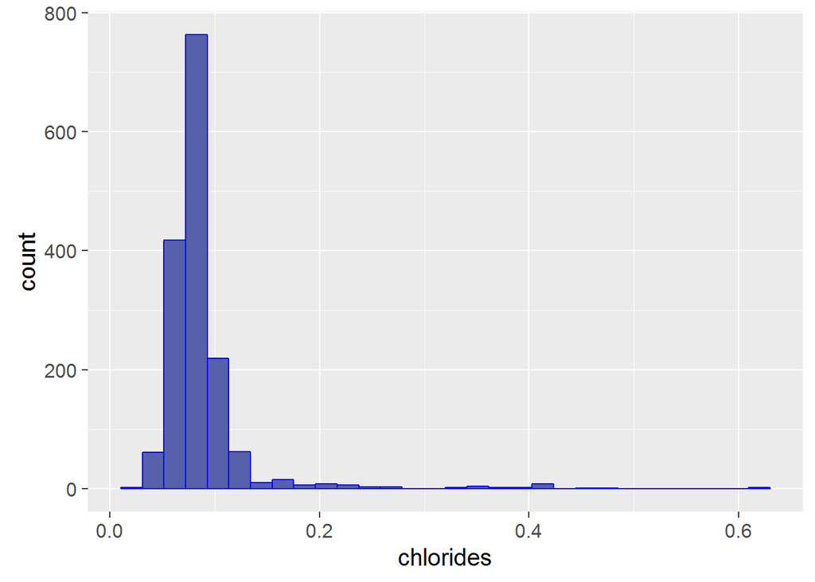

#### Normalizing data

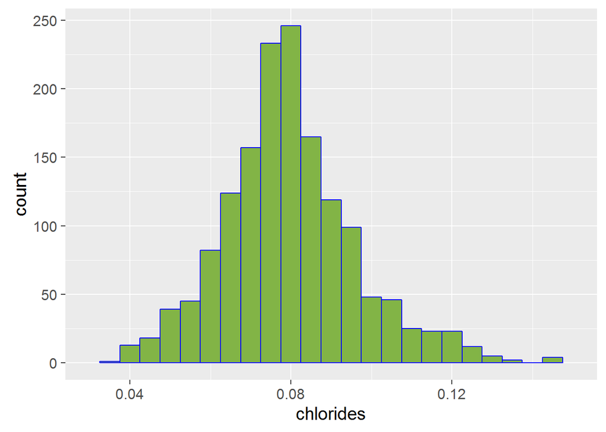

### Exploring through additional Variables

I go through the definition of the variables from the data source, there are some additional comments given to concentration or level of Sugar Residual, Total suplhatedioxide(SO2) and PH. I will check if all the wines in th e wines in the data set are with in the range of the concentration or level given about those attributes.

### Residual Sugar

It is rare to get a sugar residual less than 1grams/litre and great than 45grams/litre.Does the sugar residual in of the wines in our data set fall in the limit?

```
## [1] 2
```

```
##         X fixed.acidity volatile.acidity citric.acid residual.sugar
## 1018 1018             8             0.18        0.37            0.9
## 1019 1019             8             0.18        0.37            0.9
##      chlorides free.sulfur.dioxide total.sulfur.dioxide density   pH
## 1018     0.049                  36                  109 0.99007 2.89
## 1019     0.049                  36                  109 0.99007 2.89
##      sulphates alcohol quality quality.category
## 1018      0.44    12.7       6          Average
## 1019      0.44    12.7       6          Average
```

### Total Sulphate dioxide

Total sulphate dioxide concentration over 50 ppm is noticable in the nose and tast of wine. Let’s us check if we have wine with SO2 concentration over 50ppm.

```
## [1] 546
```

546 wines in our data set has total sulphate dioxide greater than 50ppm.

### PH

PH scale(describes how acidic or basic a wine is) is given from 0(very acidic) to 14(very basic) and most wines are between 3 to 4 pH scales.

```
## [1] 29
```

```
## [1] 2
```

### Summary on Univariate analysis

The main futures of the dataset in regard to my topic of interest (quality of Red wine) are alcohol, sulphates and volatile acidity. These factors have greater impact on the quality of red wine compared to the other variables.

Density is partly dependent on alcohol concentration and pH is a scale showing how acidic or basic a wine is. Hence, I am interested in checking the relation between alcohol and density, and volatile acidity and pH.

In order to help me with some of my analysis, I have grouped the quality variable as ‘Not Good’, ‘Average’ and ‘Good’.

There are some variables which are not normally distributed and with outliers. I have made an effort to normalize and remove outliers as much as possible using log10 and limit functions. The variables which are not normally distributed or having outliers are free sulfur dioxide and total sulfur dioxide, citric acid, residual sugar, chlorides and alcohol.

# Bivariate Plots and Analysis

### Quality with other Variables

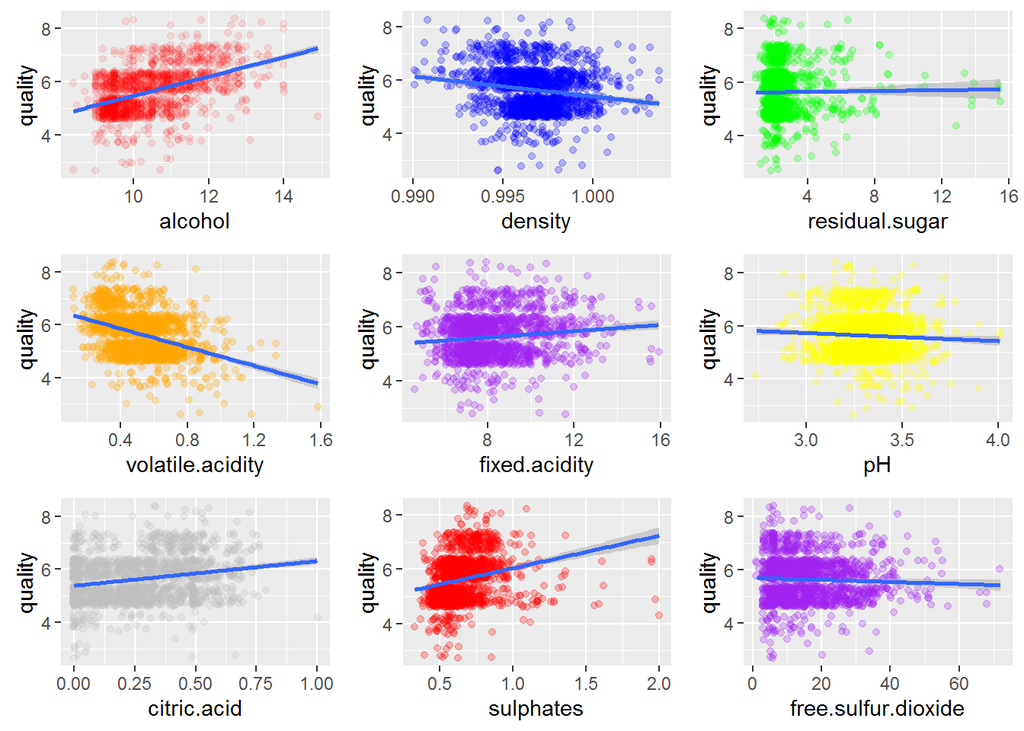

### Pearson Correlation Coefficient

```
##                             [,1]
## fixed.acidity         0.12405165
## volatile.acidity     -0.39055778
## citric.acid           0.22637251
## residual.sugar        0.01373164
## chlorides            -0.12890656
## free.sulfur.dioxide  -0.05065606
## total.sulfur.dioxide -0.18510029
## density              -0.17491923
## pH                   -0.05773139
## sulphates             0.25139708
## alcohol               0.47616632
```

The result shows the correlation between quality and alcohol, sulphates, and Volatile acidity is higher(positively and negatively) compared to other variables.

### 1. Alcohol

The Pearson correlation coefficent between quality and alcohol is 0.48. The relation between alcohol and red wine is positive which means as the concentration of alcohol increases quality of red wine.

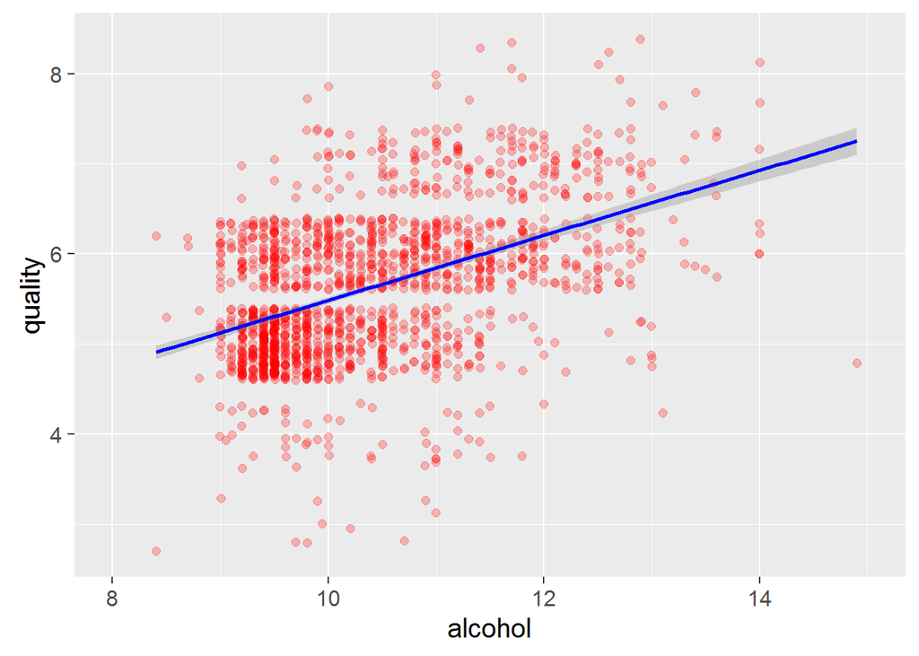

The same as the result derived from Pearson correlation, the graph show positive relation between alcohol and quality.

### 2. Sulphates

The correlation between sulphates and quality is 0.25 which is a weak positive relation.

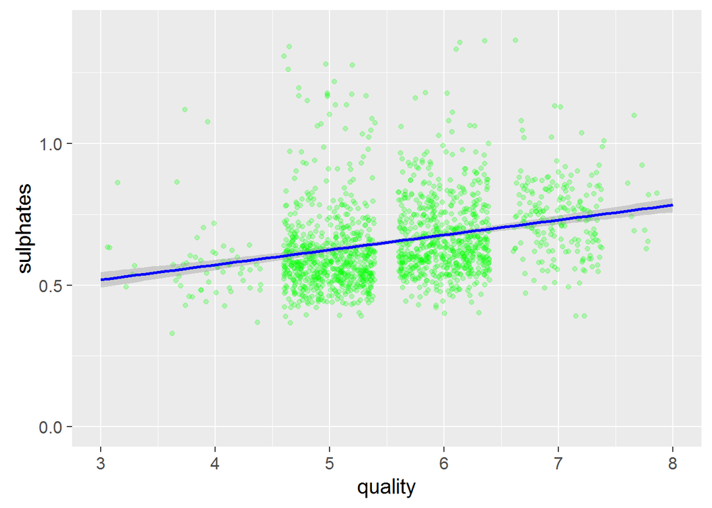

## 3. Volatile Acidity

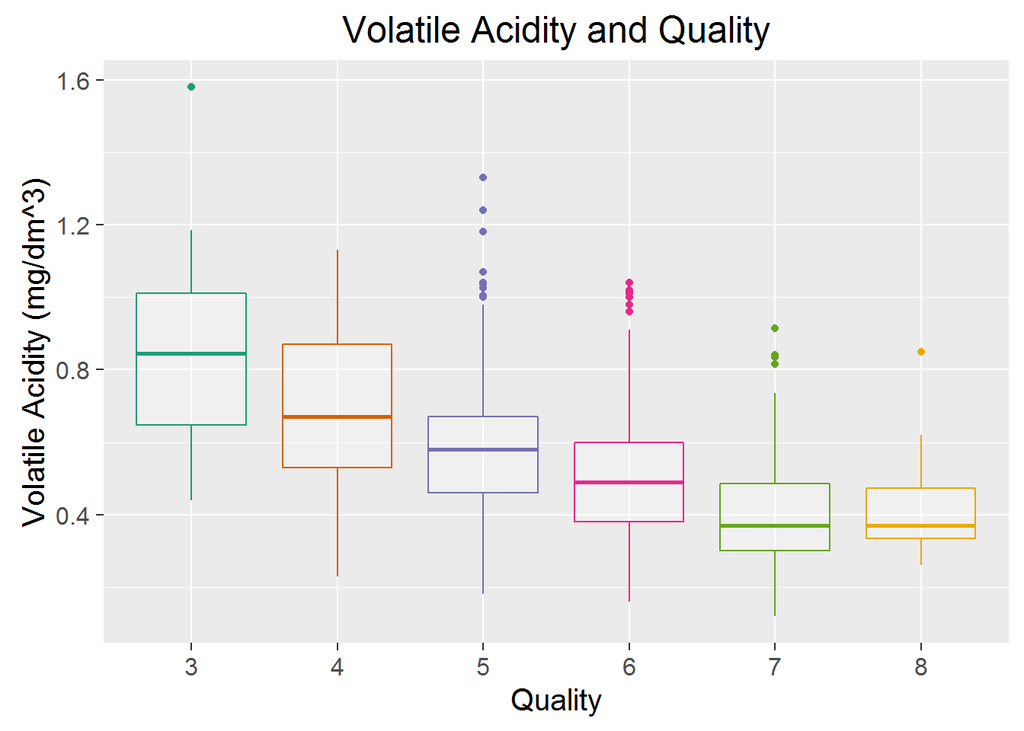

It is clearly shown in the graph that as volite Acidity decreases quality increase except in the higher qualities where the change in Volatile acidity does not make any change.

## Relation between other features

### 1.Alcohol and Density

As alcohol was the one which has strongest relation with quality, I want to check other variable which has strong relation with Alcohol.

```
##                             [,1]
## fixed.acidity        -0.06166827
## volatile.acidity     -0.20228803
## citric.acid           0.10990325
## residual.sugar        0.04207544
## chlorides            -0.22114054
## free.sulfur.dioxide  -0.06940835
## total.sulfur.dioxide -0.20565394
## density              -0.49617977
## pH                    0.20563251
## sulphates             0.09359475
```

Alcohol has the strongest negative relation with density which is -0.50.

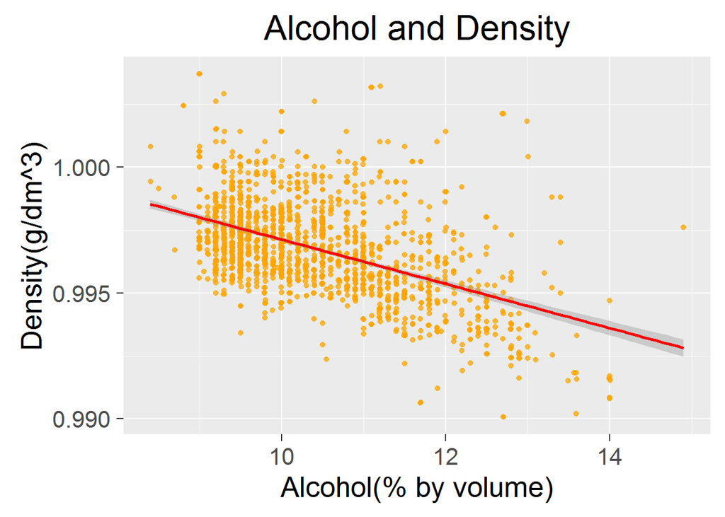

### 2. PH and Fixed Acidity

PH shows us how basic or acidic a wine is. ‘0’ represents very acidic and 14 represents very basic. I want to check how the Pearson correlation coefficent and a graph of both the variables will look like.

```
## [1] -0.6829782
```

The Pearson correlation coefficeint is -0.68 which shows strong negative relation which is as what is in line with the definition given. The pH scale increases with basic character of wine.

[figure not shown]

### Summary on Bivariate Analysis

After the Pearson correlation between quality and all the variable was checked, the coefficient of correlation is with alcohol, sulphate and volital acidity.Although the relation is not strong, it is higher betweeb the above mentioned variales and qualtiy. The relation is positive with alcohol and sulphate, and negative with volitale acidity.

Investigation was made to see if the attributes have relation among themselves other than with my topic of interest(quality), I have observed that alcohol and density has strong negative relation with Pearson Coefficient of correlation -0.50. Like wise, pH and fixed acidity have strong negative relation with -0.68 Pearson Coefficient of correlation.

The strongest relationship is between pH ad fixed acidity which is -0.68. pH and fixed Acidity has strong negative relation. While Alcohol has the strongest relation with quality of wine.

# Multivariate Plots and Analysis

### 1. Alcohol and Density with Quality

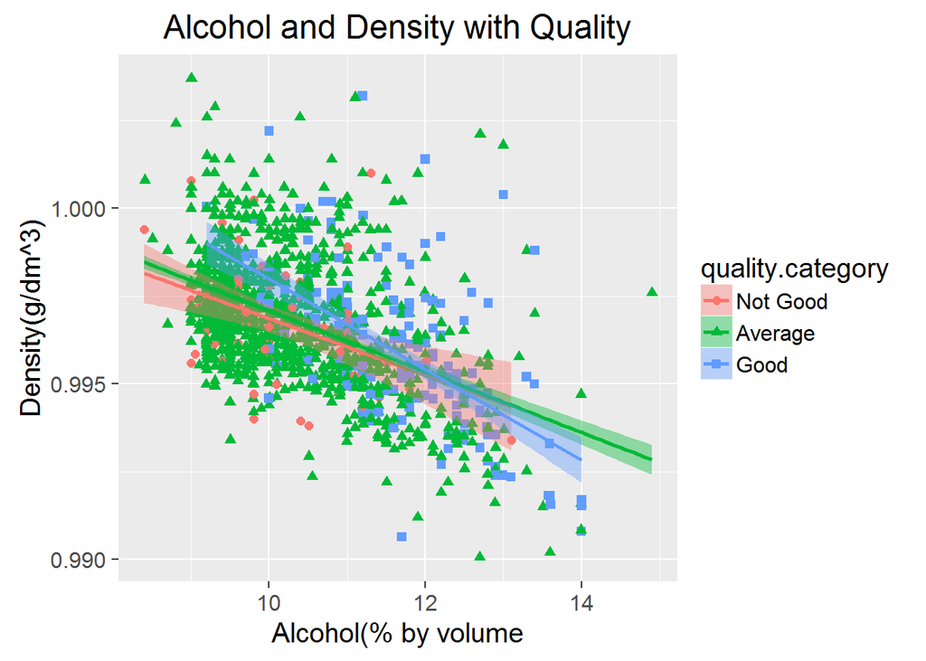

### 2. Free Sulfur dioxide and total Sulfur dioxide with Quality

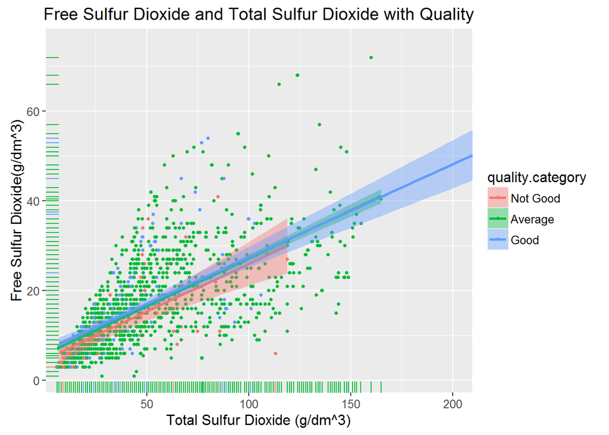

### 3. Alchol and Volatile Acidity with Quality

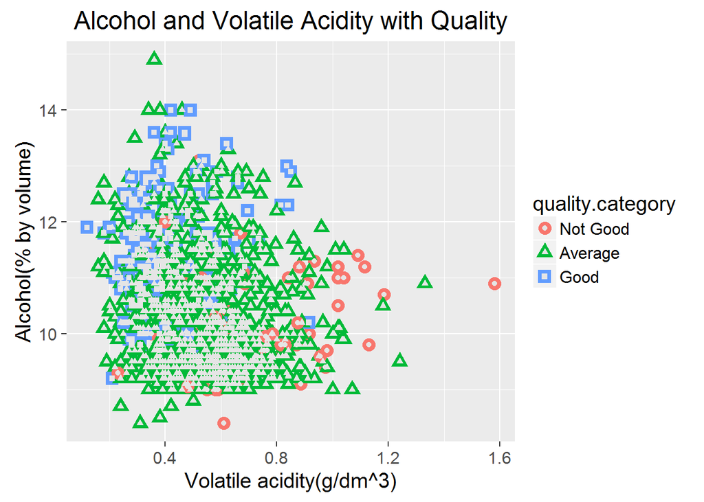

Refering the graph, we can say that with the increase of alcohol and the decrease of volatile, quality inceases as most of the ‘Good’ quality wine are on the top of the left corn of the graph.

# Final Plots and Summary

### Plot One: Quality

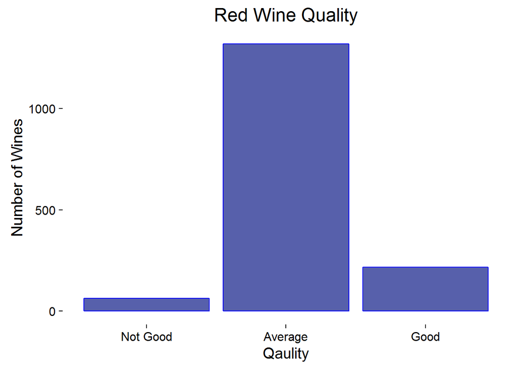

### Description One

The experts of wine have rated the wine in a scale 0 which is very bad to 10 which is excellent. There are no very bad wines and excellent wines in the data set. Most of the wines are averagely rated.

### Plot Two: Volatile Acidity and Quality

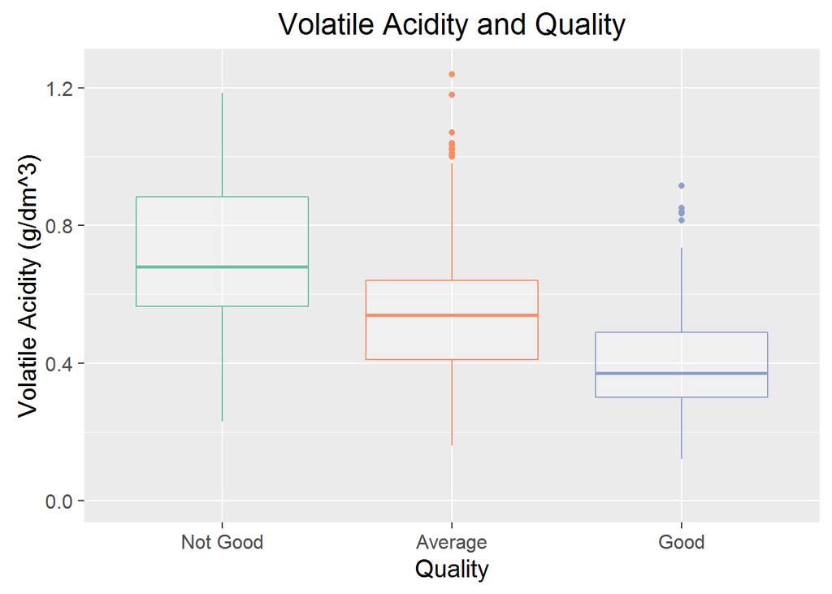

### Description Two

It is explaned clealy the relation between volatile acidity and quality with the box plot median line. The median line of the box plot is decease as volatile acidity increases. The quality of wine decrease with the increase of volatile acidity. Volatile acidity and quality has negative relation.

### Plot Three: Fixed Acidity and PH with quality

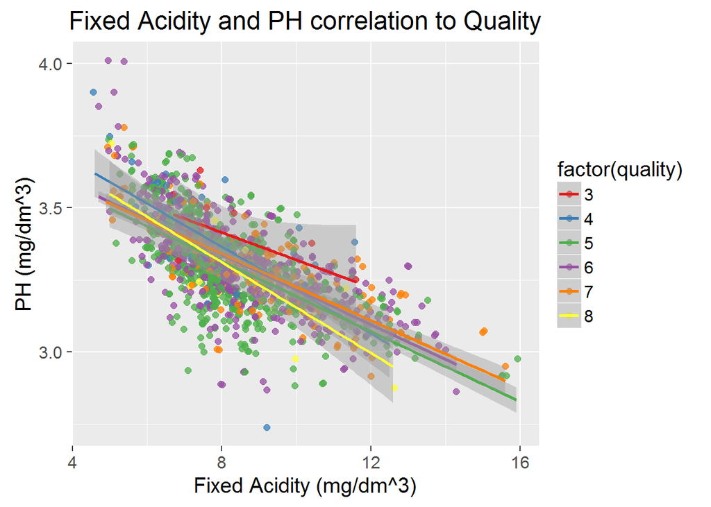

# Reflection

The above investigation shows that the quality of wine is mainly affected by the concentration of alcohol especially at the lower level. The effect of alcohol was not also that much strong. Based on our data it is not easy to explain the effect of alcohol on wine other than show us the positive correlation.

In the dataset, the quality of wine was mostly dominated by average wines( quality value ‘5’ and ‘6’), there were very few bad( quality value ‘3’ or ‘4’). The number of wine which were level as ‘3’ and ‘4’ were 63, those which were level as ‘5’ or ‘6’ were 1319 and those with ‘7’ or ‘8’ are 217. So it was not easy noticeable to see the difference in most graphs. Even look at the quality with out groupping it does not show the effect clearly. It would have been good if the number of wines in each quality scale were the same and if we have very bad and excellent scaled wines.

# Reference

- P. Cortez, A. Cerdeira, F. Almeida, T. Matos and J. Reis. Modeling wine preferences by data mining from physicochemical properties.In Decision Support Systems, Elsevier, 47(4):547-553. ISSN: 0167-9236: Retrieved from http://dx.doi.org/10.1016/j.dss.2009.05.016
- STHDA.(N.A).Statistical Tools for Highthrough Put Data Analysis: Retrieved from http://www.sthda.com/english/wiki/correlation-matrix-a-quick-start-guide-to-analyze-format-and-visualize-a-correlation-matrix-using-r-software